# Презентация по лаблраторной работе №4

Архитектура Компьютеров и Операционные Системы

Барето Виллиан Мануел

Российский университет дружбы народов, Москва, Россия

07 марта 2025

# Информация

## Докладчик

- Барето Виллиан Мануел
- Студентка НКА-03-24
- Факультет Физико-математический и естественный наук
- Российский университет дружбы народов
- [manuelbarretowillian@gmil.com]
- git@github.com:WMBarreto/study_2024-2025_os-intro.git

# Цель работы

Цель данной работы является получением навыков правильной работы с репозиториями git.

# Выполнение лабораторной работы

## Установка git-flow

Gitflow Workflow предполагает выстраивание строгой модели ветвления с учётом выпуска проекта. Сначала я включаю репозиторий copr:

[figure not shown]

включение copr

## Установка git-flow

Используя dnf install скачаю gitflow:

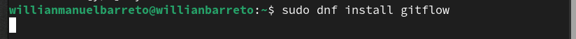

dnf install gitflow

## Установка Node.js

Для семантического версионирования и общепринятых коммитов я устанавливаю Nodejs и pnpm:

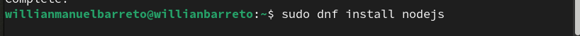

Установка Nodejs

## Установка Node.js

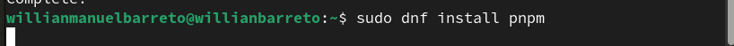

Установка pnpm

## Настройка Node.js

Запуская pnpm setup я добавляю каталог с исполняемыми файлами, устанавливаемыми yarn для работы с Node.js в переменную PATH:

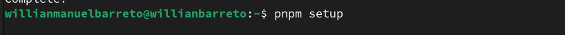

Запуск pnpm

## Настройка Node.js

Далее перелогинуюсь и выполняю source ~/.bashrc:

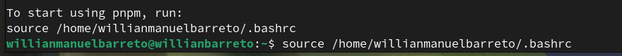

~/.bashrc

## Общепринятые коммиты

Для помощи в форматировании коммитов добавляю программу commitizen:

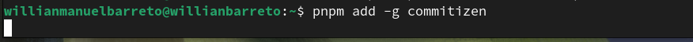

добавление commitizen

## Общепринятые коммиты

Добавляю standard-changelog для помощи в создании логов:

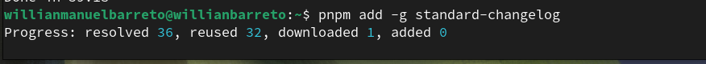

добавление standard-changelog

## Общепринятые коммиты

Создаю репозиторий на GitHub назову его git-extended:

[figure not shown]

Создание git-extended

## Общепринятые коммиты

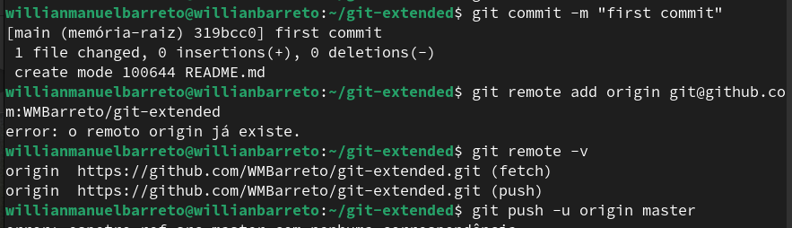

Первый коммит

## Общепринятые коммиты

Я инициализирую pnpm:

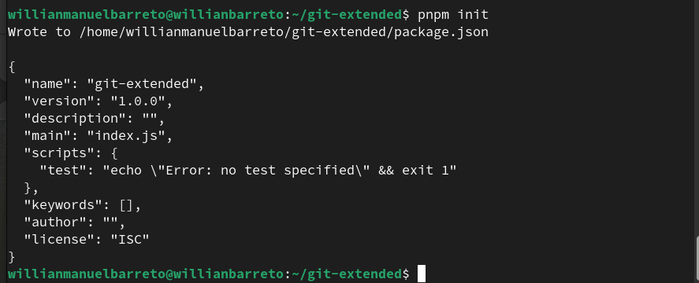

Инициализирование pnpm

## Общепринятые коммиты

Заполняю несколько параметров пакета (файл package.json):

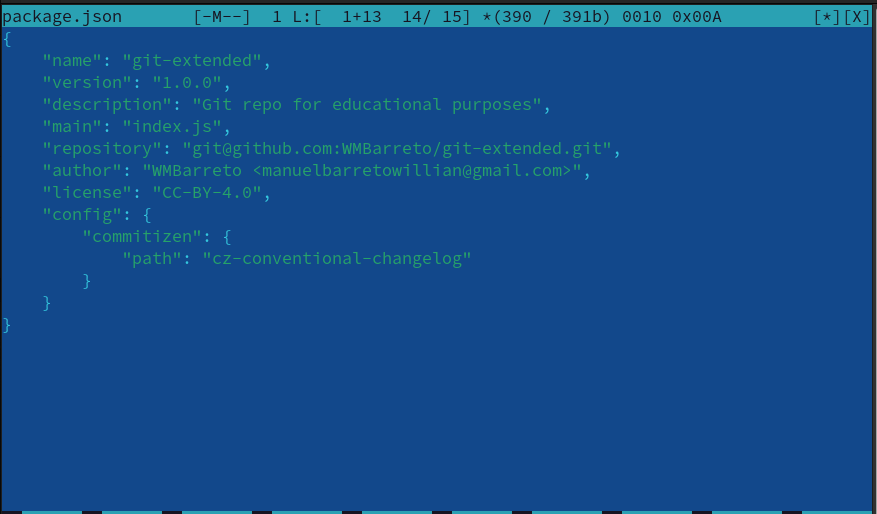

Заполнение пакетов

## Общепринятые коммиты

Добавляю новые файлы и выполняю коммит (указиваю тип коммит (feat)) и отправляю на гит:

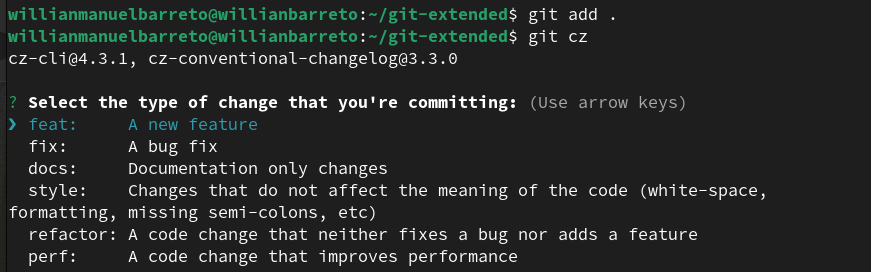

Добавление новых файлов

## Общепринятые коммиты

Инициализирую git-flow и указываю ветки:

[figure not shown]

Инициализирование git-flow

## Общепринятые коммиты

Преверяю что я на ветке develop с промощью git branch:

[figure not shown]

Проверка ветки

## Общепринятые коммиты

Загружаю весь репозиторий в хранилище с помощью git push –all:

[figure not shown]

Загрузка репозиторий

## Общепринятые коммиты

Установливаю внешнюю ветку как вышестоящую для этой ветки (develop):

[figure not shown]

установка внешней ветки

## Общепринятые коммиты

Создаю релиз с версией 1.0.0 и журнал изменений (standard-changelog)::

[figure not shown]

Создание релиза

## Общепринятые коммиты

Добавляю журнал изменений в индекс:

[figure not shown]

Добавление журнала изменений

## Общепринятые коммиты

Залью релизную ветку в основную ветку:

[figure not shown]

Замена ветки

## Общепринятые коммиты

Отправляю данные на github:

[figure not shown]

Отправка на гит

## Общепринятые коммиты

Создаю релиз на github. Для этого использую утилиты работы с github gh (gh release create):

[figure not shown]

Создание релиза

## Общепринятые коммиты

Создаю ветку для новой функциональности:

[figure not shown]

Создание ветки feature_branch

## Общепринятые коммиты

Далее, продолжаю работу c git как обычно. Создаю релиз с версией 1.2.3:

[figure not shown]

Создание релиза с версией 1.2.3

## Общепринятые коммиты

Обновляю номер версии в файле package.json в 1.2.3:

[figure not shown]

Обновление номера версии

## Общепринятые коммиты

Создаю журнал изменений (standard-changelog):

[figure not shown]

Создание нового журнала изменений

## Общепринятые коммиты

Добавляю журнал изменений в индекс:

[figure not shown]

Добавление журнала

## Общепринятые коммиты

Залью релизную ветку в основную ветку:

[figure not shown]

Замена ветки

## Общепринятые коммиты

Отправляю данные на github:

[figure not shown]

Отправка данных

## Общепринятые коммиты

Создаю релиз на github с комментарием из журнала изменений:

[figure not shown]

Cоздание релиза

# Выводы

При выполнение работы я получила навыки правильной работы с репозиториями git.